# Web page Phishing Detection project

### Présentation des données

Le phishing est une méthode de cyberfraude courante et efficace, exploitée par les cybercriminels pour dérober des informations personnelles et financières. Avec l’augmentation de notre dépendance à l’internet pour nos activités quotidiennes, les attaques de phishing sont devenues plus sophistiquées et difficiles à identifier. Une étude d’Intel a révélé que 97 % des experts en sécurité échouent à distinguer les courriels de phishing des courriels authentiques.

Contenu du Jeu de Données

Le jeu de données fourni contient 11 430 URL, chacune décrite par 87 caractéristiques distinctes. Ces données sont conçues pour servir de référence aux systèmes de détection de phishing basés sur l’apprentissage automatique. Les caractéristiques sont divisées en trois classes :

- 56 basées sur la structure et la syntaxe des URL,
- 24 extraites du contenu des pages web correspondantes,
- 7 obtenues par des requêtes auprès de services externes.

Le jeu de données est équilibré, composé à 50 % d’URL de phishing et à 50 % d’URL légitimes, ce qui est idéal pour l’entraînement de modèles de classification.

#### 1. Visualisation du jeu de données

```r
head(df)
```

```
## # A tibble: 6 × 88
##   length_url length_hostname    ip nb_dots nb_hyphens nb_at nb_qm nb_and nb_or
##        <dbl>           <dbl> <dbl>   <dbl>      <dbl> <dbl> <dbl>  <dbl> <dbl>
## 1         37              19     0       3          0     0     0      0     0
## 2         77              23     1       1          0     0     0      0     0
## 3        126              50     1       4          1     0     1      2     0
## 4         18              11     0       2          0     0     0      0     0
## 5         55              15     0       2          2     0     0      0     0
## 6         32              24     0       3          1     0     0      0     0
## # ℹ 79 more variables: nb_eq <dbl>, nb_underscore <dbl>, nb_tilde <dbl>,
## #   nb_percent <dbl>, nb_slash <dbl>, nb_star <dbl>, nb_colon <dbl>,
## #   nb_comma <dbl>, nb_semicolumn <dbl>, nb_dollar <dbl>, nb_space <dbl>,
## #   nb_www <dbl>, nb_com <dbl>, nb_dslash <dbl>, http_in_path <dbl>,
## #   https_token <dbl>, ratio_digits_url <dbl>, ratio_digits_host <dbl>,
## #   punycode <dbl>, port <dbl>, tld_in_path <dbl>, tld_in_subdomain <dbl>,
## #   abnormal_subdomain <dbl>, nb_subdomains <dbl>, prefix_suffix <dbl>, …
```

#### 2. Distribution des classes

[output not shown]

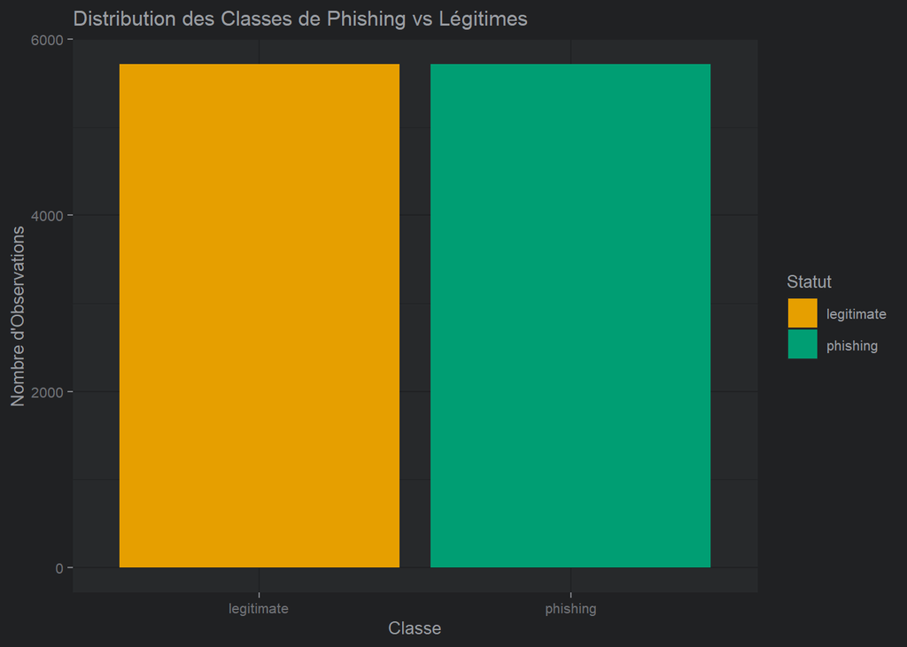

```r
df$status <- as.factor(df$status)
ggplot(df, aes(x=status, fill=status)) +
  geom_bar() +
  labs(x="Classe", y="Nombre d'Observations", fill="Statut") +
  ggtitle("Distribution des Classes de Phishing vs Légitimes")
```

#### 3. Distribution des caractéristiques

[output not shown]

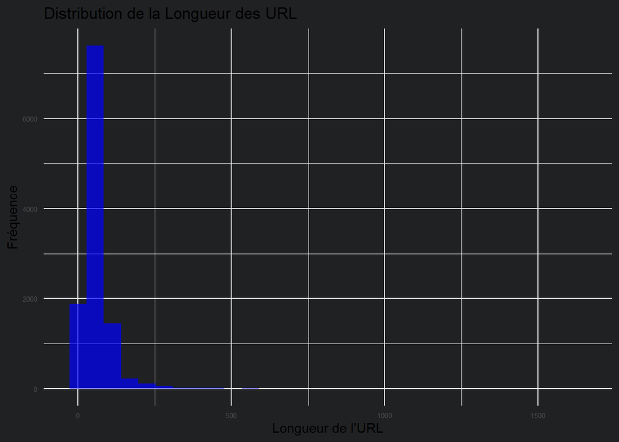

```r
# Histogramme pour 'length_url'
ggplot(df, aes(x=length_url)) +
  geom_histogram(bins=30, fill="blue", alpha=0.7) +
  labs(x="Longueur de l'URL", y="Fréquence") +
  ggtitle("Distribution de la Longueur des URL") +
  theme_minimal()
```

[output not shown]

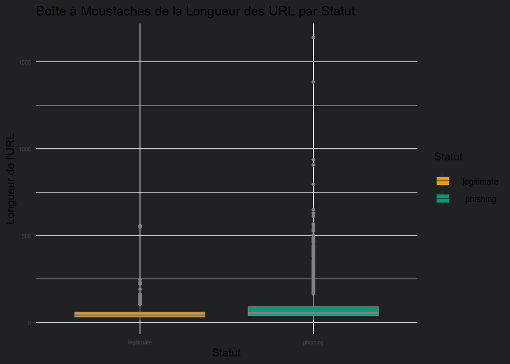

```r
# Boîte à moustaches pour 'length_url'
ggplot(df, aes(y=length_url, x=status, fill=status)) +
  geom_boxplot() +
  labs(x="Statut", y="Longueur de l'URL", fill="Statut") +
  ggtitle("Boîte à Moustaches de la Longueur des URL par Statut") +
  theme_minimal()
```

[output not shown]

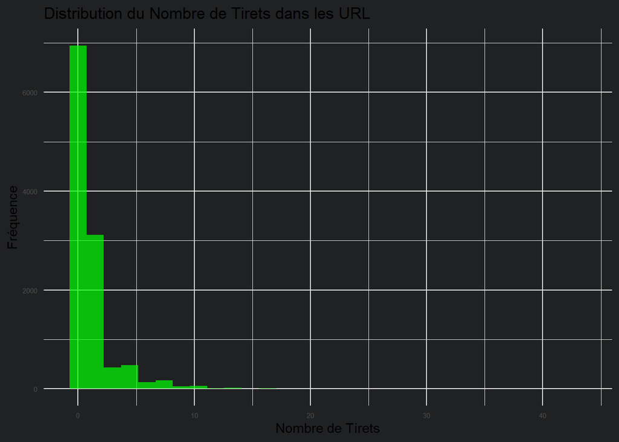

```r
# Histogramme pour 'nb_hyphens'
ggplot(df, aes(x=nb_hyphens)) +
  geom_histogram(bins=30, fill="green", alpha=0.7) +
  labs(x="Nombre de Tirets", y="Fréquence") +
  ggtitle("Distribution du Nombre de Tirets dans les URL") +
  theme_minimal()
```

[output not shown]

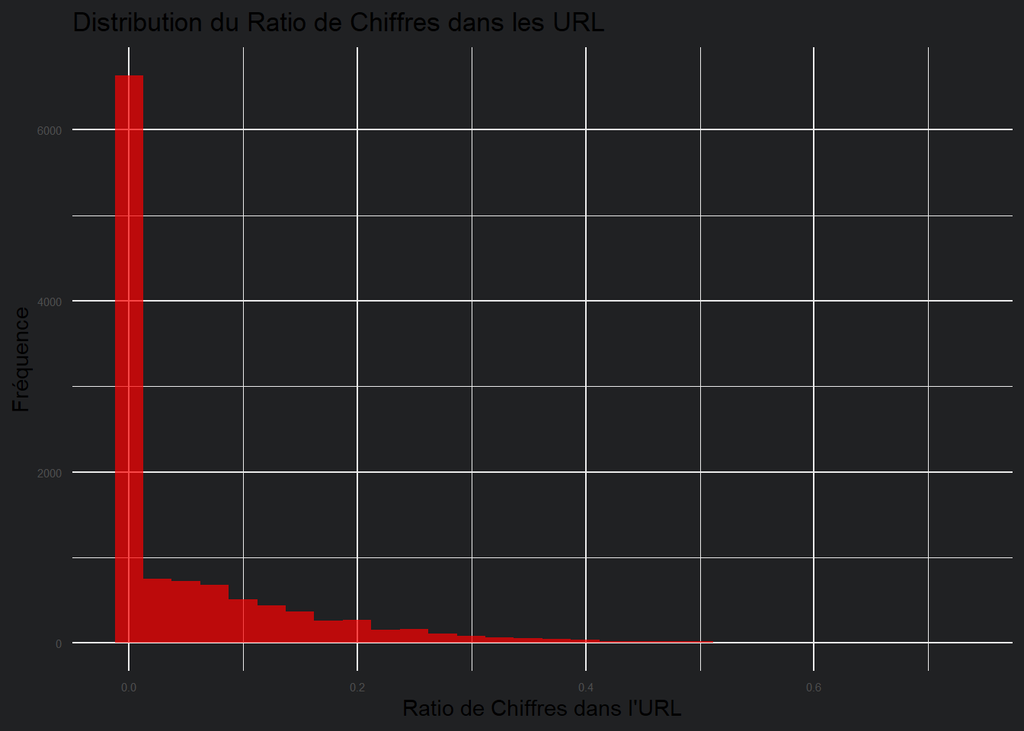

```r
# Histogramme pour 'ratio_digits_url'
ggplot(df, aes(x=ratio_digits_url)) +
  geom_histogram(bins=30, fill="red", alpha=0.7) +
  labs(x="Ratio de Chiffres dans l'URL", y="Fréquence") +
  ggtitle("Distribution du Ratio de Chiffres dans les URL") +
  theme_minimal()
```

#### 4. Corrélation des caractéristiques

```r
numeric_columns <- sapply(df, is.numeric)
cor_matrix <- cor(df[, numeric_columns], use = "complete.obs")
```

[output not shown]

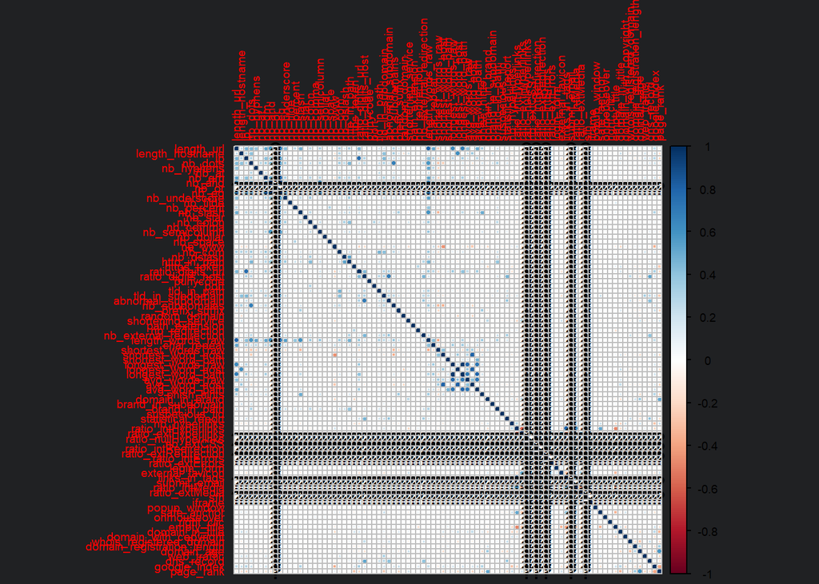

```r
corrplot(cor_matrix, method = "circle", tl.cex = 0.6, cl.cex = 0.6)
```

### Préparation des données

```r
indxTrain <- createDataPartition(df$status, p = 0.75, list = FALSE)
DTrain <- df[indxTrain, ]
DTest <- df[-indxTrain, ]

cat("Nombre d'observations dans l'ensemble d'entraînement:", nrow(DTrain), "\n")
```

```
## Nombre d'observations dans l'ensemble d'entraînement: 8574
```

```r
cat("Nombre d'observations dans l'ensemble de test:", nrow(DTest), "\n")
```

```
## Nombre d'observations dans l'ensemble de test: 2856
```

Test

# 1. prédictions

```r
ctrl <- trainControl(method = "none")
set.seed(123) # Pour la reproductibilité
fit.knn <- train(status ~ ., data = DTrain, method = "knn", tuneGrid = data.frame(k = 5), trControl = ctrl)
predictions <- predict(fit.knn, newdata = DTest)
```

# 2. évaluation du modèle

Dans cette partie de l’analyse, nous évaluons la performance du modèle des k-plus proches voisins (K-NN) que nous avons entraîné pour la détection de sites de phishing. L’utilisation d’une matrice de confusion nous permet de comparer les prédictions du modèle par rapport aux valeurs réelles. La matrice de confusion est un outil puissant pour mesurer la précision, la sensibilité, la spécificité et d’autres métriques importantes de la performance du modèle.

```r
# Matrice de confusion
confusionMatrix <- confusionMatrix(predictions, DTest$status)

print(confusionMatrix$table)
```

```
##             Reference
## Prediction   legitimate phishing
##   legitimate       1148      207
##   phishing          280     1221
```

```r
print(confusionMatrix$overall['Accuracy'])
```

```
##  Accuracy
## 0.8294818
```

```r
errorRate <- 1 - confusionMatrix$overall['Accuracy']
print(errorRate)
```

```
##  Accuracy
## 0.1705182
```

# 3. Choix du K

Dans cette section de votre analyse, vous avez effectué une recherche du nombre optimal de voisins k pour le modèle des k-plus proches voisins (K-NN) à l’aide de la validation croisée 10-fold. Cela implique de diviser l’ensemble de données d’entraînement en 10 parties, d’utiliser 9 d’entre elles pour l’entraînement et une pour la validation, et de répéter ce processus 10 fois avec des parties différentes à chaque fois pour la validation.

[output not shown]

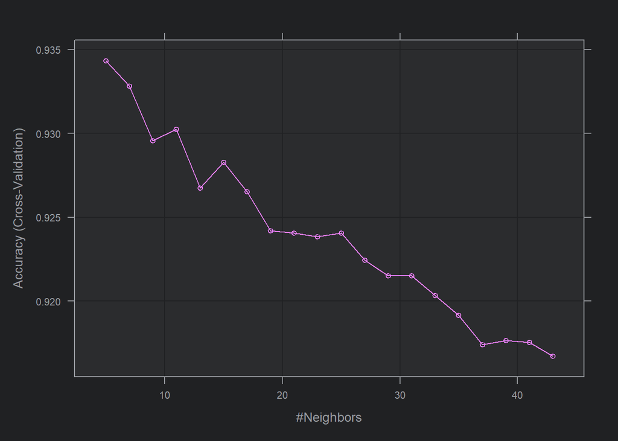

```r
# Recherche du meilleur k
ctrl <- trainControl(method = "cv", number = 10) # 10-fold cross-validation

# Entraînement du modèle avec une recherche de différents k
knnFit <- train(status ~ ., data = DTrain, method = "knn", trControl = ctrl, tuneLength = 20, preProcess = c("center", "scale"))

# Visualisation des résultats
plot(knnFit)
```

```r
print(knnFit$results)
```

```
##     k  Accuracy     Kappa  AccuracySD    KappaSD
## 1   5 0.9343347 0.8686691 0.010254667 0.02050964
## 2   7 0.9328197 0.8656389 0.007728234 0.01545715
## 3   9 0.9295545 0.8591087 0.006873565 0.01374768
## 4  11 0.9302539 0.8605074 0.008865910 0.01773352
## 5  13 0.9267553 0.8535098 0.007333999 0.01467047
## 6  15 0.9282714 0.8565419 0.008291507 0.01658657
## 7  17 0.9265224 0.8530440 0.009617340 0.01923932
## 8  19 0.9241894 0.8483785 0.010464123 0.02093180
## 9  21 0.9240728 0.8481452 0.009721543 0.01944712
## 10 23 0.9238391 0.8476778 0.008347075 0.01669698
## 11 25 0.9240719 0.8481427 0.008799558 0.01760496
## 12 27 0.9224394 0.8448777 0.008094354 0.01619430
## 13 29 0.9215060 0.8430111 0.009723424 0.01945240
## 14 31 0.9215052 0.8430093 0.011082740 0.02217211
## 15 33 0.9203386 0.8406760 0.011617933 0.02324274
## 16 35 0.9191719 0.8383428 0.010811910 0.02163001
## 17 37 0.9174238 0.8348467 0.010368719 0.02074394
## 18 39 0.9176571 0.8353131 0.009926541 0.01986014
## 19 41 0.9175403 0.8350794 0.010240956 0.02048873
## 20 43 0.9167241 0.8334471 0.010489437 0.02098500
```

```r
print(knnFit$bestTune)
```

```
##   k
## 1 5
```

```r
# Estimation de l'erreur de prédiction avec le meilleur k sur les données de test
bestK <- knnFit$bestTune$k
predictionsBestK <- predict(knnFit, newdata = DTest)
confusionMatrixBestK <- confusionMatrix(predictionsBestK, DTest$status)
errorRateBestK <- 1 - confusionMatrixBestK$overall['Accuracy']
print(errorRateBestK)
```

```
##   Accuracy
## 0.05672269
```

Il est également important de noter les écarts-types des précisions (AccuracySD) et des scores Kappa (KappaSD), qui fournissent une indication de la variabilité de la performance du modèle à travers les différentes itérations de la validation croisée. Des écarts-types plus faibles sont préférables car ils impliquent une performance plus constante du modèle.